# python Insurances project

### Import Library

```python
import numpy as np
import pandas as pd
import seaborn as sns
import matplotlib.pyplot as plt
```

#### Uploading Csv File

```python
df = pd.read_csv(r"insurance.csv")
df
```

|  | age | sex | bmi | children | smoker | region | charges |
| --- | --- | --- | --- | --- | --- | --- | --- |
| 0 | 19 | female | 27.900 | 0 | yes | southwest | 16884.92400 |
| 1 | 18 | male | 33.770 | 1 | no | southeast | 1725.55230 |
| 2 | 28 | male | 33.000 | 3 | no | southeast | 4449.46200 |
| 3 | 33 | male | 22.705 | 0 | no | northwest | 21984.47061 |
| 4 | 32 | male | 28.880 | 0 | no | northwest | 3866.85520 |
| ... | ... | ... | ... | ... | ... | ... | ... |
| 1333 | 50 | male | 30.970 | 3 | no | northwest | 10600.54830 |
| 1334 | 18 | female | 31.920 | 0 | no | northeast | 2205.98080 |
| 1335 | 18 | female | 36.850 | 0 | no | southeast | 1629.83350 |
| 1336 | 21 | female | 25.800 | 0 | no | southwest | 2007.94500 |
| 1337 | 61 | female | 29.070 | 0 | yes | northwest | 29141.36030 |

1338 rows × 7 columns

### Data Preprocessing

```python
df.head()
```

|  | age | sex | bmi | children | smoker | region | charges |
| --- | --- | --- | --- | --- | --- | --- | --- |
| 0 | 19 | female | 27.900 | 0 | yes | southwest | 16884.92400 |
| 1 | 18 | male | 33.770 | 1 | no | southeast | 1725.55230 |
| 2 | 28 | male | 33.000 | 3 | no | southeast | 4449.46200 |
| 3 | 33 | male | 22.705 | 0 | no | northwest | 21984.47061 |
| 4 | 32 | male | 28.880 | 0 | no | northwest | 3866.85520 |

```python
df.tail()
```

|  | age | sex | bmi | children | smoker | region | charges |
| --- | --- | --- | --- | --- | --- | --- | --- |
| 1333 | 50 | male | 30.97 | 3 | no | northwest | 10600.5483 |
| 1334 | 18 | female | 31.92 | 0 | no | northeast | 2205.9808 |
| 1335 | 18 | female | 36.85 | 0 | no | southeast | 1629.8335 |
| 1336 | 21 | female | 25.80 | 0 | no | southwest | 2007.9450 |
| 1337 | 61 | female | 29.07 | 0 | yes | northwest | 29141.3603 |

```python
df.shape
```

```
(1338, 7)
```

```python
df.columns
```

```
Index(['age', 'sex', 'bmi', 'children', 'smoker', 'region', 'charges'], dtype='object')
```

```python
df.dtypes
```

```
age           int64
sex          object
bmi         float64
children      int64
smoker       object
region       object
charges     float64
dtype: object
```

```python
df.nunique()
```

```
age           47
sex            2
bmi          548
children       6
smoker         2
region         4
charges     1337
dtype: int64
```

```python
df.describe ()
```

|  | age | bmi | children | charges |
| --- | --- | --- | --- | --- |
| count | 1338.000000 | 1338.000000 | 1338.000000 | 1338.000000 |
| mean | 39.207025 | 30.663397 | 1.094918 | 13270.422265 |
| std | 14.049960 | 6.098187 | 1.205493 | 12110.011237 |
| min | 18.000000 | 15.960000 | 0.000000 | 1121.873900 |
| 25% | 27.000000 | 26.296250 | 0.000000 | 4740.287150 |
| 50% | 39.000000 | 30.400000 | 1.000000 | 9382.033000 |
| 75% | 51.000000 | 34.693750 | 2.000000 | 16639.912515 |
| max | 64.000000 | 53.130000 | 5.000000 | 63770.428010 |

```python
df.isnull()
```

|  | age | sex | bmi | children | smoker | region | charges |
| --- | --- | --- | --- | --- | --- | --- | --- |
| 0 | False | False | False | False | False | False | False |
| 1 | False | False | False | False | False | False | False |
| 2 | False | False | False | False | False | False | False |
| 3 | False | False | False | False | False | False | False |
| 4 | False | False | False | False | False | False | False |
| ... | ... | ... | ... | ... | ... | ... | ... |
| 1333 | False | False | False | False | False | False | False |
| 1334 | False | False | False | False | False | False | False |
| 1335 | False | False | False | False | False | False | False |
| 1336 | False | False | False | False | False | False | False |
| 1337 | False | False | False | False | False | False | False |

1338 rows × 7 columns

```python
print(df.isnull().sum())
```

```
age         0
sex         0
bmi         0
children    0
smoker      0
region      0
charges     0
dtype: int64
```

```python
df.info()
```

```
<class 'pandas.core.frame.DataFrame'>
RangeIndex: 1338 entries, 0 to 1337
Data columns (total 7 columns):
 #   Column    Non-Null Count  Dtype
---  ------    --------------  -----
 0   age       1338 non-null   int64
 1   sex       1338 non-null   object
 2   bmi       1338 non-null   float64
 3   children  1338 non-null   int64
 4   smoker    1338 non-null   object
 5   region    1338 non-null   object
 6   charges   1338 non-null   float64
dtypes: float64(2), int64(2), object(3)
memory usage: 73.3+ KB
```

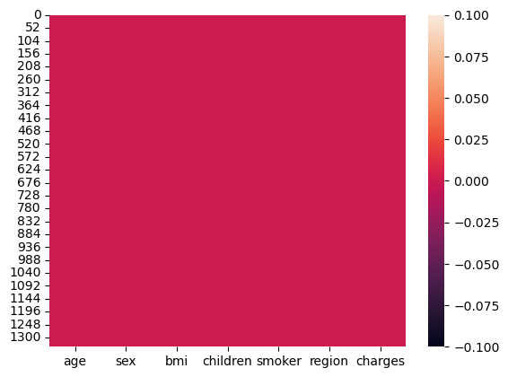

```python
sns.heatmap(df.isnull())
plt.show()
```

```python
print(df.duplicated().sum())
```

```
1
```

```python
pd.get_dummies(df)
```

|  | age | bmi | children | charges | sex_female | sex_male | smoker_no | smoker_yes | region_northeast | region_northwest | region_southeast | region_southwest |
| --- | --- | --- | --- | --- | --- | --- | --- | --- | --- | --- | --- | --- |
| 0 | 19 | 27.900 | 0 | 16884.92400 | 1 | 0 | 0 | 1 | 0 | 0 | 0 | 1 |
| 1 | 18 | 33.770 | 1 | 1725.55230 | 0 | 1 | 1 | 0 | 0 | 0 | 1 | 0 |
| 2 | 28 | 33.000 | 3 | 4449.46200 | 0 | 1 | 1 | 0 | 0 | 0 | 1 | 0 |
| 3 | 33 | 22.705 | 0 | 21984.47061 | 0 | 1 | 1 | 0 | 0 | 1 | 0 | 0 |
| 4 | 32 | 28.880 | 0 | 3866.85520 | 0 | 1 | 1 | 0 | 0 | 1 | 0 | 0 |
| ... | ... | ... | ... | ... | ... | ... | ... | ... | ... | ... | ... | ... |
| 1333 | 50 | 30.970 | 3 | 10600.54830 | 0 | 1 | 1 | 0 | 0 | 1 | 0 | 0 |
| 1334 | 18 | 31.920 | 0 | 2205.98080 | 1 | 0 | 1 | 0 | 1 | 0 | 0 | 0 |
| 1335 | 18 | 36.850 | 0 | 1629.83350 | 1 | 0 | 1 | 0 | 0 | 0 | 1 | 0 |
| 1336 | 21 | 25.800 | 0 | 2007.94500 | 1 | 0 | 1 | 0 | 0 | 0 | 0 | 1 |
| 1337 | 61 | 29.070 | 0 | 29141.36030 | 1 | 0 | 0 | 1 | 0 | 1 | 0 | 0 |

1338 rows × 12 columns

```python
duplicates = df.duplicated()
print(duplicates)
```

```
0       False
1       False
2       False
3       False
4       False
        ...
1333    False
1334    False
1335    False
1336    False
1337    False
Length: 1338, dtype: bool
```

```python
df = df.drop_duplicates()
df
```

|  | age | sex | bmi | children | smoker | region | charges |
| --- | --- | --- | --- | --- | --- | --- | --- |
| 0 | 19 | female | 27.900 | 0 | yes | southwest | 16884.92400 |
| 1 | 18 | male | 33.770 | 1 | no | southeast | 1725.55230 |
| 2 | 28 | male | 33.000 | 3 | no | southeast | 4449.46200 |
| 3 | 33 | male | 22.705 | 0 | no | northwest | 21984.47061 |
| 4 | 32 | male | 28.880 | 0 | no | northwest | 3866.85520 |
| ... | ... | ... | ... | ... | ... | ... | ... |
| 1333 | 50 | male | 30.970 | 3 | no | northwest | 10600.54830 |
| 1334 | 18 | female | 31.920 | 0 | no | northeast | 2205.98080 |
| 1335 | 18 | female | 36.850 | 0 | no | southeast | 1629.83350 |
| 1336 | 21 | female | 25.800 | 0 | no | southwest | 2007.94500 |
| 1337 | 61 | female | 29.070 | 0 | yes | northwest | 29141.36030 |

1337 rows × 7 columns

```python
# Drop rows with any missing values
df_cleaned = df.dropna()

df_cleaned
```

|  | age | sex | bmi | children | smoker | region | charges |
| --- | --- | --- | --- | --- | --- | --- | --- |
| 0 | 19 | female | 27.900 | 0 | yes | southwest | 16884.92400 |
| 1 | 18 | male | 33.770 | 1 | no | southeast | 1725.55230 |
| 2 | 28 | male | 33.000 | 3 | no | southeast | 4449.46200 |
| 3 | 33 | male | 22.705 | 0 | no | northwest | 21984.47061 |
| 4 | 32 | male | 28.880 | 0 | no | northwest | 3866.85520 |
| ... | ... | ... | ... | ... | ... | ... | ... |
| 1333 | 50 | male | 30.970 | 3 | no | northwest | 10600.54830 |
| 1334 | 18 | female | 31.920 | 0 | no | northeast | 2205.98080 |
| 1335 | 18 | female | 36.850 | 0 | no | southeast | 1629.83350 |
| 1336 | 21 | female | 25.800 | 0 | no | southwest | 2007.94500 |
| 1337 | 61 | female | 29.070 | 0 | yes | northwest | 29141.36030 |

1337 rows × 7 columns

```python
df_cleaned.to_csv('insurance.csv.csv', index=False)
df
```

|  | age | sex | bmi | children | smoker | region | charges |
| --- | --- | --- | --- | --- | --- | --- | --- |
| 0 | 19 | female | 27.900 | 0 | yes | southwest | 16884.92400 |
| 1 | 18 | male | 33.770 | 1 | no | southeast | 1725.55230 |
| 2 | 28 | male | 33.000 | 3 | no | southeast | 4449.46200 |
| 3 | 33 | male | 22.705 | 0 | no | northwest | 21984.47061 |
| 4 | 32 | male | 28.880 | 0 | no | northwest | 3866.85520 |
| ... | ... | ... | ... | ... | ... | ... | ... |
| 1333 | 50 | male | 30.970 | 3 | no | northwest | 10600.54830 |
| 1334 | 18 | female | 31.920 | 0 | no | northeast | 2205.98080 |
| 1335 | 18 | female | 36.850 | 0 | no | southeast | 1629.83350 |
| 1336 | 21 | female | 25.800 | 0 | no | southwest | 2007.94500 |
| 1337 | 61 | female | 29.070 | 0 | yes | northwest | 29141.36030 |

1337 rows × 7 columns

### Histograms:

Visualize the distribution of numerical variables such as 'age,' 'bmi,' and 'charges' using histograms

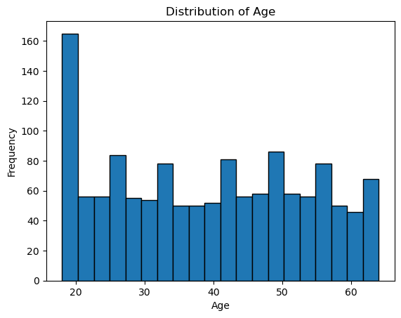

```python
import matplotlib.pyplot as plt

#Histrogram for 'age'
plt.hist(df['age'],bins =20,edgecolor ='k')
plt.xlabel('Age')
plt.ylabel('Frequency')
plt.title("Distribution of Age")
plt.show()
```

- The horizontal axis (x-axis) represents the 'Age' values in your dataset.
- The vertical axis (y-axis) represents the frequency or count of observations that fall into each age range or bin.
- The data range of ages is divided into 20 equally spaced intervals or bins, and each bin represents a specific range of ages.
- The height of each bar in the histogram represents the number of individuals (frequency) within that age range.

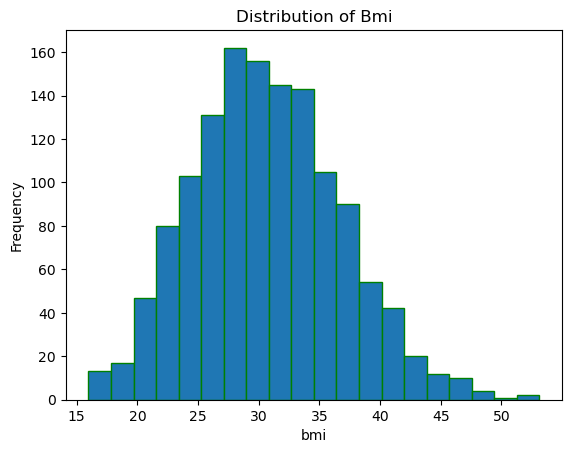

```python
#Histrogram for 'bmi'
plt.hist(df['bmi'],bins =20,edgecolor ='g')
plt.xlabel('bmi')
plt.ylabel('Frequency')
plt.title("Distribution of Bmi")
plt.show()
```

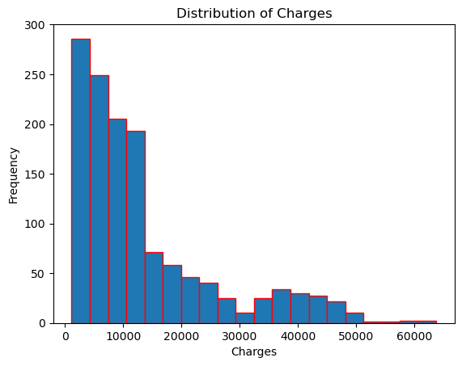

```python
plt.hist(df['charges'],bins = 20,edgecolor = 'r')
plt.xlabel('Charges')
plt.ylabel('Frequency')
plt.title('Distribution of Charges')
plt.show()
```

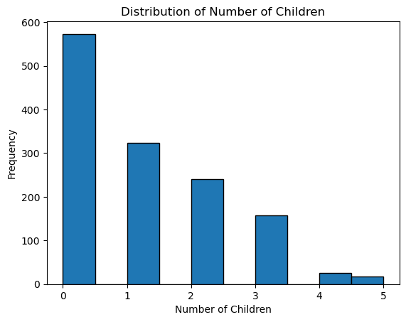

```python
# Create a histogram for children
plt.hist(df['children'], bins=10, edgecolor='k')
plt.xlabel('Number of Children')
plt.ylabel('Frequency')
plt.title('Distribution of Number of Children')
plt.show()
```

### Box Plots:

Use box plots to visualize the distribution and outliers in numerical variable

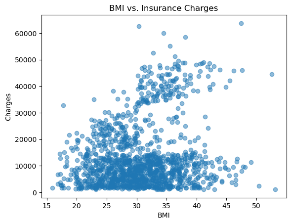

```python
# Scatter plot for 'bmi' vs. 'charges'
plt.scatter(df['bmi'], df['charges'], alpha=0.5)
plt.xlabel('BMI')
plt.ylabel('Charges')
plt.title('BMI vs. Insurance Charges')
plt.show()
```

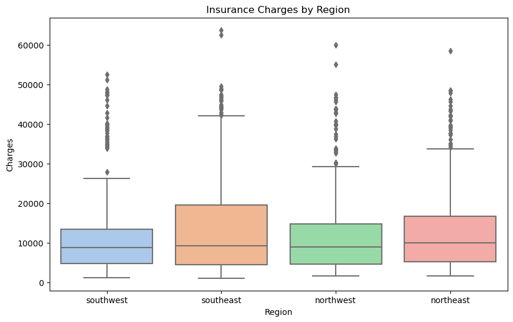

```python
# Box plot for 'region' vs. 'charges'
plt.figure(figsize=(10, 6))
sns.boxplot(x='region', y='charges', data=df, palette='pastel')
plt.xlabel('Region')
plt.ylabel('Charges')
plt.title('Insurance Charges by Region')
plt.show()
```

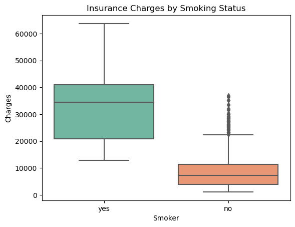

```python
import seaborn as sns

# Box plot for 'smoker' vs. 'charges'
sns.boxplot(x='smoker', y='charges', data=df, palette='Set2')
plt.xlabel('Smoker')
plt.ylabel('Charges')
plt.title('Insurance Charges by Smoking Status')
plt.show()
```

### The box plot compares the distribution of insurance charges for smokers ('yes') and non-smokers ('no').

Smokers tend to have significantly higher insurance charges on average compared to non-smokers.

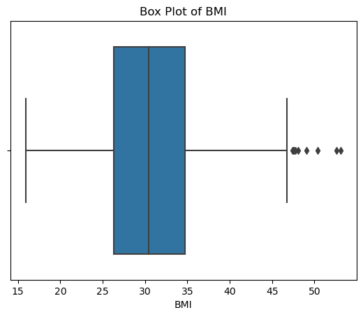

```python
import seaborn as sns

# Box plot for bmi
sns.boxplot(x='bmi',data =df)
plt.xlabel('BMI')
plt.title("Box Plot of BMI")
plt.show()
```

### Scatter Plots:

Explore relationships between numerical variables, such as 'age' vs. 'charges.'

Scatter plots are used to visualize the relationship between two numerical variables. They display individual data points as points on a two-dimensional plane, with one variable on the x-axis and the other on the y-axis. Scatter plots are useful for understanding patterns, trends, and potential correlations or relationships between variables

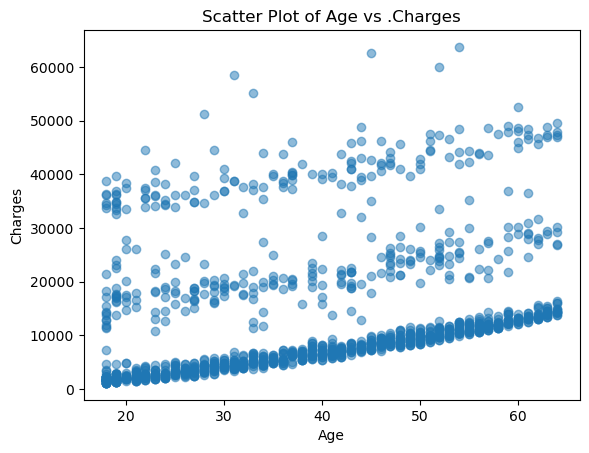

```python
plt.scatter(df['age'],df['charges'],alpha= 0.5)
plt.xlabel('Age')
plt.ylabel('Charges')
plt.title('Scatter Plot of Age vs .Charges')
plt.show()
```

### Interpretation:

- In this scatter plot, each point represents an individual in the dataset, with their 'Age' on the x-axis and 'Charges' (insurance charges) on the y-axis.
- The alpha parameter (set to 0.5) makes the points slightly transparent, which helps when there are overlapping points.
- By examining the scatter plot, you can assess whether there is a visual pattern or trend in the data. In this case, you are exploring whether there's a relationship between age and insurance charges.
- If points tend to cluster in a certain way (e.g., they form a diagonal line), it may indicate a positive or negative correlation between the two variables. In this plot, you can see that as age increases, charges also tend to increase. This suggests a potential positive correlation.

### Scatter Plot for 'BMI' vs. 'Charges':

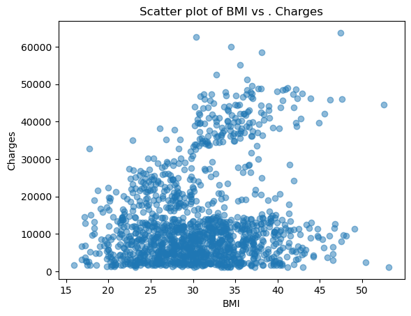

```python
import matplotlib.pyplot as plt

plt.scatter(df['bmi'],df['charges'], alpha =0.5)
plt.xlabel('BMI')
plt.ylabel('Charges')
plt.title('Scatter plot of BMI vs . Charges')
plt.show()
```

### Interpretation:

- This scatter plot explores the relationship between 'BMI' (Body Mass Index) and 'Charges' (insurance charges).
- Each point represents an individual, with their 'BMI' on the x-axis and 'Charges' on the y-axis.
- By examining the scatter plot, you can assess whether there's any visual pattern or trend in the data. In this case, you are exploring whether there's a relationship between BMI and insurance charges.
- If points tend to cluster in a certain way, it may indicate a correlation between the two variables. In this plot, there doesn't seem to be a strong linear correlation, but you can still see some spread in charges across different BMI values.

### Bar Charts:

Create bar charts to visualize the distribution of categorical variables like 'sex,' 'smoker,' and 'region.'

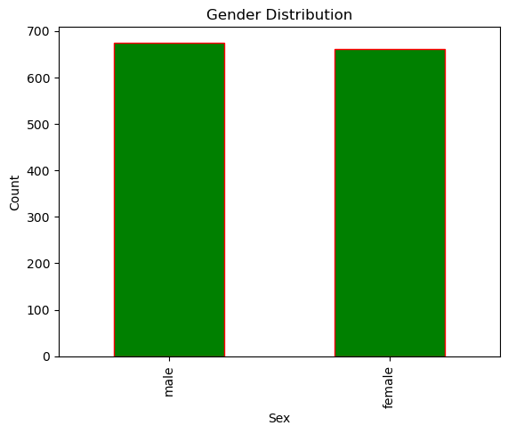

```python
# Bar chart for 'sex'
import matplotlib.pyplot as plt

gender_counts = df['sex'].value_counts()
gender_counts.plot(kind ='bar', color ='green', edgecolor = 'r')
plt.xlabel('Sex')
plt.ylabel('Count')
plt.title('Gender Distribution')
plt.show()
```

### Interpretation:

- In this bar chart, the x-axis represents the 'Sex' categories ('female' and 'male'), and the y-axis represents the count or frequency of each category .
- The chart displays the distribution of genders within the dataset.
- You can see how many individuals are categorized as 'female' and 'male' in the dataset.
- In this example, it appears that the dataset has a roughly balanced distribution of genders, with a similar count of 'female' and 'male' individuals.

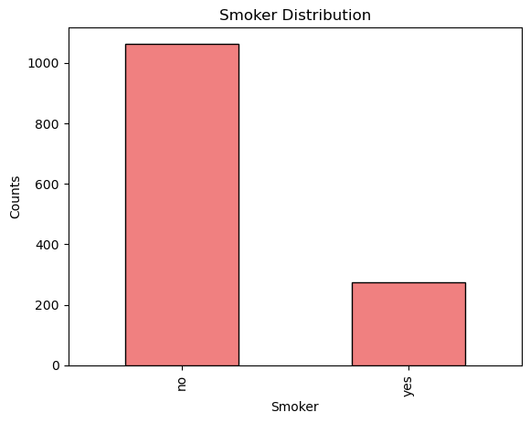

```python
#smoker

import matplotlib.pyplot as plt

smoker_counts = df['smoker'].value_counts()
smoker_counts.plot(kind ='bar',color = 'lightcoral',edgecolor ='black')
plt.xlabel('Smoker')
plt.ylabel('Counts')
plt.title('Smoker Distribution')
plt.show()
```

### Interpretation:

- This bar chart displays the distribution of 'Smoker' categories ('yes' and 'no') in the dataset.
- The x-axis represents the 'Smoker' categories, and the y-axis represents the count or frequency of each category.
- You can see the number of smokers ('yes') and non-smokers ('no') in the dataset.
- In this example, it appears that there are significantly more non-smokers ('no') than smokers ('yes') in the dataset.

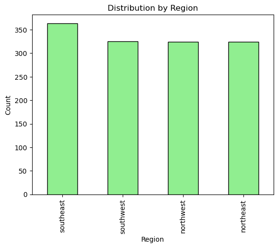

```python
import matplotlib.pyplot as plt

# Count the frequency of individuals in each region
region_counts = df['region'].value_counts()
# Create a bar chart
region_counts.plot(kind='bar', color='lightgreen', edgecolor='black')
plt.xlabel('Region')
plt.ylabel('Count')
plt.title('Distribution by Region')
plt.show()
```

### Interpretation:

- This bar chart illustrates the distribution of individuals in different regions ('northeast,' 'northwest,' 'southeast,' and 'southwest').
- The x-axis represents the regions, and the y-axis represents the count or frequency of individuals in each region.
- You can observe how many individuals are from each region in the dataset. In this example, you can see the distribution of individuals across the four regions.

### Count Plots:

Use count plots to display the count of categorical values in specific categories, e.g., count of smokers vs. non-smoker

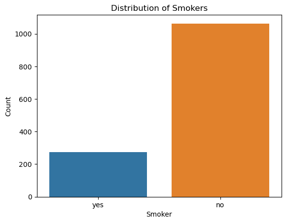

```python
# Count plot for 'smoker'
sns.countplot(x='smoker', data=df)
plt.xlabel('Smoker')
plt.ylabel('Count')
plt.title('Distribution of Smokers')
plt.show()
```

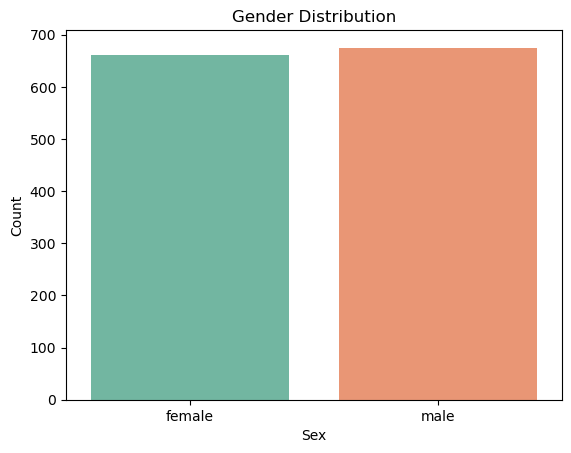

```python
import seaborn as sns
import matplotlib.pyplot as plt

# Create a count plot for 'sex'
sns.countplot(x='sex', data=df, palette='Set2')
plt.xlabel('Sex')
plt.ylabel('Count')
plt.title('Gender Distribution')
plt.show()
```

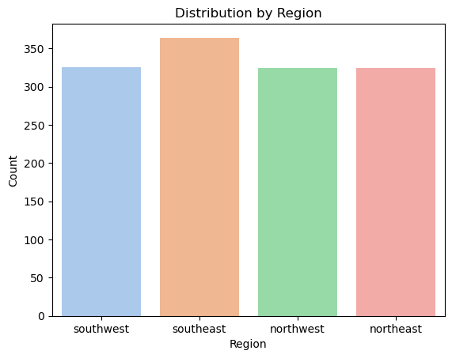

```python
# Create a count plot for 'region'
sns.countplot(x='region', data=df, palette='pastel')
plt.xlabel('Region')
plt.ylabel('Count')
plt.title('Distribution by Region')
plt.show()
```

#### Correlation Analysis

```python
import pandas as pd


# Calculate the correlation matrix
correlation_matrix = df[['age', 'bmi', 'children', 'charges']].corr()

# Print the correlation matrix
print(correlation_matrix)
```

```
               age       bmi  children   charges
age       1.000000  0.109344  0.041536  0.298308
bmi       0.109344  1.000000  0.012755  0.198401
children  0.041536  0.012755  1.000000  0.067389
charges   0.298308  0.198401  0.067389  1.000000
```

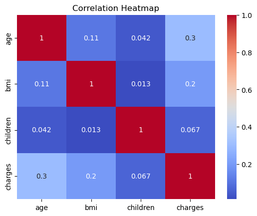

```python
# Correlation heatmap
correlation_matrix = df.corr()
sns.heatmap(correlation_matrix, annot=True, cmap='coolwarm')
plt.title('Correlation Heatmap')
plt.show()
```

#### Grouped Analysis by 'Sex':

```python
# Group the data by 'sex' and calculate the mean age and average charges for each gender group
grouped_by_sex = df.groupby('sex')[['age', 'charges']].mean()

# Display the grouped analysis
print("Grouped Analysis by Sex:")
print(grouped_by_sex)
```

```
Grouped Analysis by Sex:
              age       charges
sex
female  39.503021  12569.578844
male    38.946667  13974.998864
```

#### Interpretation:

- This analysis groups the data by 'sex' and calculates the mean 'age' and average 'charges' for each gender group ('female' and 'male').
- You can observe how average age and charges differ between the two genders.

### Grouped Analysis by 'Smoker':

```python
# Group the data by 'smoker' status and calculate the mean BMI and average charges for each group
grouped_by_smoker = df.groupby('smoker')[['bmi', 'charges']].mean()

# Display the grouped analysis
print("Grouped Analysis by Smoker Status:")
print(grouped_by_smoker)
```

```
Grouped Analysis by Smoker Status:
              bmi       charges
smoker
no      30.651853   8440.660307
yes     30.708449  32050.231832
```

### Interpretation:

- This analysis groups the data by 'smoker' status ('yes' and 'no') and calculates the mean 'bmi' and average 'charges' for each group.
- You can see how average BMI and charges differ between smokers and non-smokers.

### Grouped Analysis by 'Region':

```python
# Group the data by 'region' and calculate the median age and average charges for each region
grouped_by_region = df.groupby('region')[['age', 'charges']].median()

# Display the grouped analysis
print("Grouped Analysis by Region:")
print(grouped_by_region)
```

```
Grouped Analysis by Region:
            age       charges
region
northeast  39.5  10057.652025
northwest  39.0   8976.977250
southeast  39.0   9294.131950
southwest  39.0   8798.593000
```

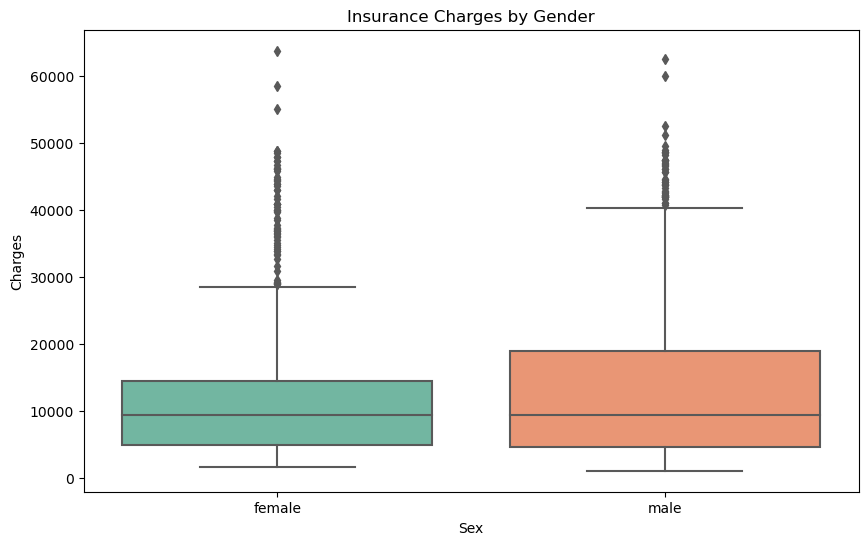

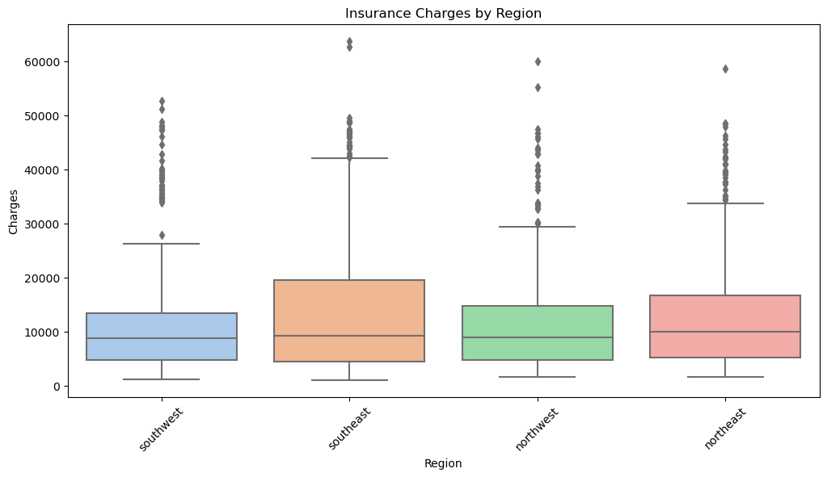

```python
# Box plot for 'sex' vs. 'charges'
plt.figure(figsize=(10, 6))
sns.boxplot(x='sex', y='charges', data=df, palette='Set2')
plt.xlabel('Sex')
plt.ylabel('Charges')
plt.title('Insurance Charges by Gender')
plt.show()

# Box plot for 'region' vs. 'charges'
plt.figure(figsize=(12, 6))
sns.boxplot(x='region', y='charges', data=df, palette='pastel')
plt.xlabel('Region')
plt.ylabel('Charges')
plt.title('Insurance Charges by Region')
plt.xticks(rotation=45)
plt.show()
```

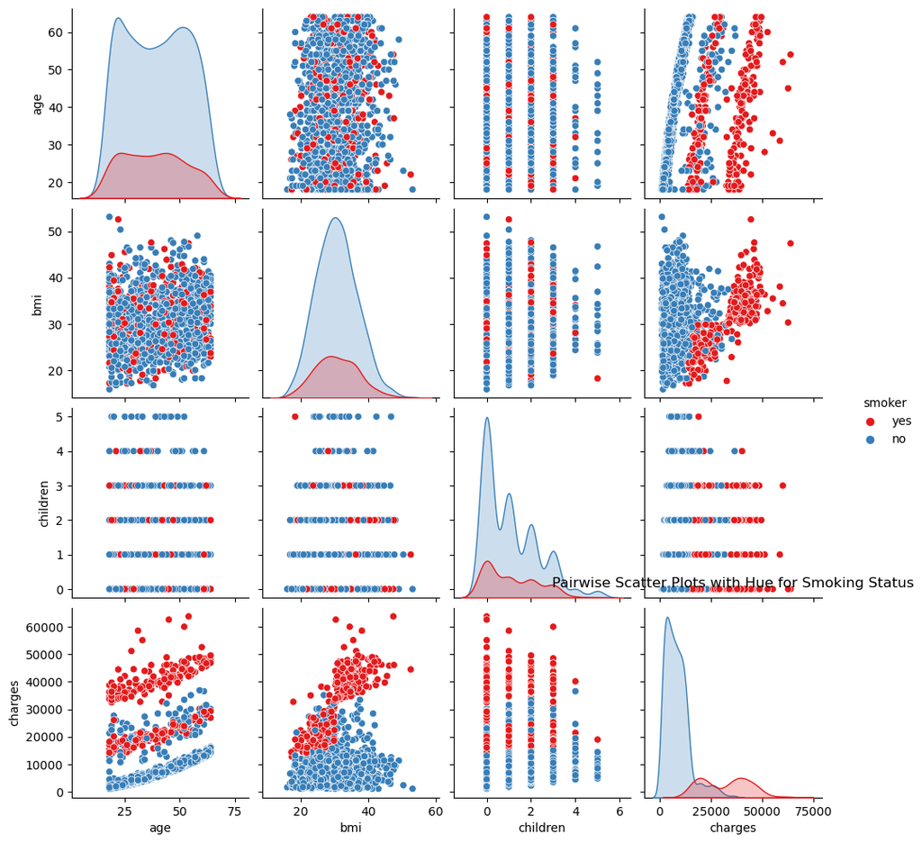

```python
# Pairplot with hue for 'smoker'
sns.pairplot(df, hue='smoker', palette='Set1')
plt.title('Pairwise Scatter Plots with Hue for Smoking Status')
plt.show()
```

### Explanation:

The pairplot creates scatter plots for all possible pairs of numerical variables (age, BMI, children, and charges). Data points are color-coded by smoking status ('yes' or 'no')

### Based on the provided dataset and the analyses performed, here are some insights and conclusions that can be drawn:

Gender Distribution:

- The dataset has a relatively balanced distribution of genders, with a similar count of 'female' and 'male' individuals.

Smoking Habits:

- A significant portion of individuals in the dataset are non-smokers ('no'), while a smaller percentage are smokers ('yes').

Regional Distribution:

- Individuals are distributed across four regions: 'northeast,' 'northwest,' 'southeast,' and 'southwest.' The dataset provides representation from different geographic areas.

Age Distribution:

- The age distribution in the dataset spans a wide range, with individuals ranging from young adults to seniors. The distribution appears relatively uniform, with no strong skewness.

Insurance Charges:

- Insurance charges vary significantly across individuals, with some individuals having low charges and others having very high charges. The distribution of charges appears to be right-skewed, with a few individuals incurring exceptionally high costs.

Correlations:

  insurance charges.
- There is no strong correlation between the number of children and insurance charges.

Group Differences:

- Smokers tend to have higher average insurance charges compared to non-smokers, suggesting that smoking status may influence insurance costs. Differences in insurance charges across regions exist, with some regions having higher average charges than others.

Machine Learning Potential:

- The dataset provides opportunities for machine learning tasks, including regression to predict insurance charges, classification to predict smoking status, and other predictive modeling tasks.

Hypothesis Testing:

- Hypothesis testing can be applied to investigate specific research questions, such as whether smoking status significantly affects insurance charges or if there are regional differences in charges.

In conclusion, the dataset contains valuable information about insurance charges and individual characteristics. The insights gained from exploratory data analysis, correlation analysis, and grouped analysis can guide further research and analysis, such as hypothesis testing or machine learning modeling, to address specific questions or objectives related to healthcare costs and insurance.